# cellAnnotator: Cell Type Annotation Using Support Vector Machine

Junhui Li

2 June 2025

#### Abstract

cellAnnotator is an R package that provides tools for annotating cell types in single-cell RNA sequencing data using Support Vector Machine (SVM) classification. This package enables researchers to leverage known cell type reference datasets to accurately classify cells in query datasets.

#### Package

cellAnnotator 0.99.0

# 1 Introduction

The `cellAnnotator` package provides a comprehensive workflow for cell type annotation in single-cell RNA sequencing (scRNA-seq) data using Support Vector Machine (SVM) classification. This vignette demonstrates the complete workflow from data preparation to model evaluation and visualization.

# 2 Workflow Overview

The annotation process consists of the following main steps:

1. Data preparation and loading
2. Reference dataset splitting
3. Expression data normalization
4. Gene filtering
5. Feature gene selection
6. SVM classifier building
7. Model evaluation
8. Visualization and interpretation
9. Model saving and loading

# 3 Step-by-Step Guide

## 3.1 Step 1: Data Preparation

First, we load the necessary reference and query datasets:

```r
library(cellAnnotator)

# Load reference datasets
data("reference_meta")  # Reference metadata
data("reference_expr")  # Reference expression data

# Load query datasets
data("query_meta")      # Query metadata
data("query_expr")      # Query expression data

# Note: The package will automatically find common genes between reference and query datasets
```

## 3.2 Step 2: Reference Dataset Splitting

Split the reference dataset into training and testing sets:

```r
# Split reference data into training and testing sets
alldataset <- splitTrainTest(
  reference_meta,
  reference_expr,
  groupBy = "cellType",
  sampleID = "cell",
  splitParameter = "ratio"
)
```

## 3.3 Step 3: Expression Data Normalization

Normalize the expression data to ensure consistent scaling:

```r
# Normalize training data
trainNorExp <- normalizeSCExp(
  alldataset$trainExplanatoryData,
  dThresh = 0.25
)

# Normalize testing data
testNorExp <- normalizeSCExp(
  alldataset$testExplanatoryData,
  dThresh = 0.25
)
```

## 3.4 Step 4: Gene Filtering

Filter genes based on expression characteristics:

```r
# Filter genes based on expression patterns
filterGene <- filterSCGene(
  trainNorExp,
  mu = 2,
  alpha1 = 0.1,
  alpha2 = 0.01,
  threshold = 0.25
)
```

## 3.5 Step 5: Feature Gene Selection

Identify the most informative genes for classification:

```r
# Select feature genes (this step may take 30+ minutes for large datasets)
responseData <- alldataset$trainResponseData$cellType
uniqueFeatureGene <- findFeatureGene(
  responseData,
  trainNorExp,
  filteredGene = filterGene,
  topX = 20,
  reverse = TRUE
)
```

## 3.6 Step 6: SVM Classifier Building

Build the SVM classifier using the selected features:

```r
# Prepare training data
x <- t(as.matrix(trainNorExp[uniqueFeatureGene,]))
y <- as.factor(alldataset$trainResponseData$cellType)

# Build SVM classifier
classifier <- buildSVMclassifier(x, y)
```

## 3.7 Step 7: Model Evaluation

Evaluate the classifier using the test dataset:

```r
# Prepare test data
testX <- t(as.matrix(testNorExp[uniqueFeatureGene,]))
yPred <- predictWithclassifier(classifier, testX)

# Evaluate predictions
testY <- as.factor(alldataset$testResponseData$cellType)
names(testY) <- alldataset$testResponseData$cell
evaluatedResult <- evaluateClassifier(yPred, testY)
```

## 3.8 Step 8: Visualization

Generate various visualizations to interpret the results:

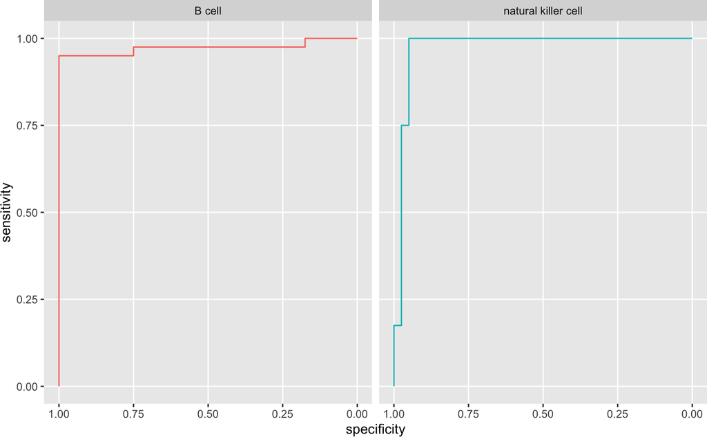

```r
# ROC curve
plotROC(evaluatedResult)
```

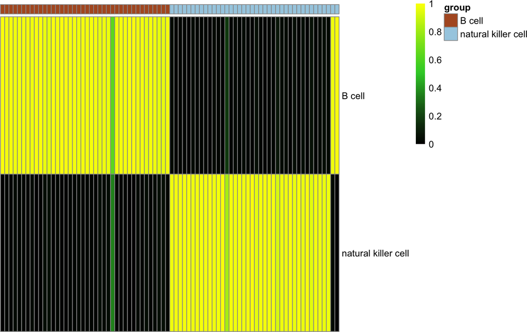

```r
# Heatmap of predictions
plotHeatmap(yPred, testY)
```

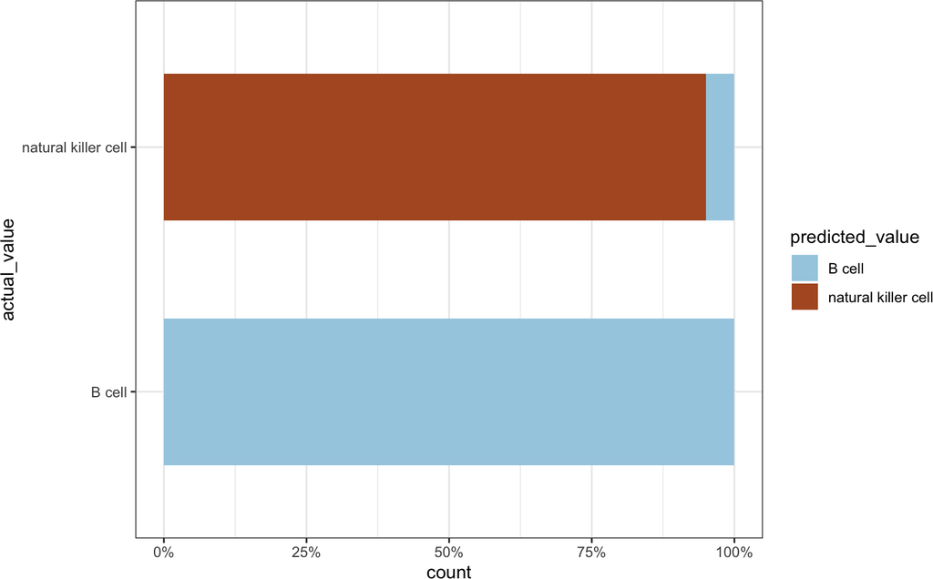

```r
# Attribution plot
plotAttr(yPred, testY)
```

## 3.9 Step 9: Model Persistence

Save and load the trained classifier:

```r
# Save classifier
saveClassifier(classifier, file = "classifier.rds")

# Load classifier
classifier <- loadClassifier("classifier.rds")
```